# Statistick_Inferenz_2_4

# Portfolio für Statistik und Datenanalyse Teil 2: Statistische Inferenz

## Library code chunk: Der Code chunk beinhaltet alle libraries die fuer die nachfolgenden Code chunks benoetigt werden. Es ist wichtig, alle benoetigten libraries hier zu laden, damit sie in den folgenden Analysen zur Verfuegung stehen.

@all: Place all libraries here

```r
library(tidyverse)
library(broom)
library(infer)
```

## Setup code chunk: Dieser Code chunk enthält alle Einstellungen, die für die nachfolgenden Code chunks relevant sind. Hier können beispielsweise globale Optionen für die Darstellung von Plots oder die Ausgabe von Ergebnissen festgelegt werden.

@all: Place all settings here

## Data code chunk: Dieser Code chunk ist für das Laden und Vorbereiten der Daten zuständig. Hier werden die Datensätze eingelesen, überprüft und gegebenenfalls bereinigt oder transformiert, um sie für die Analyse vorzubereiten. Es ist wichtig, alle Schritte der Datenvorbereitung hier zu dokumentieren, damit die Analysen nachvollziehbar sind.

@all: Place all data loading code here

```r
#laden der Daten mit einer Funktion, die Fehler und Warnungen abfängt, um die Robustheit des Einlesens zu erhöhen. Die Funktion safe_read_csv verwendet tryCatch, um mögliche Probleme beim Einlesen der CSV-Dateien zu behandeln und gibt informative Nachrichten aus, falls Fehler oder Warnungen auftreten.
safe_read_csv <- function(path, sep = ";", header = TRUE, dec = ".") {
  tryCatch(
    {
      data <- read.csv(path, sep = sep, header = header, dec = dec)
      message("Successfully loaded: ", path)
      return(data)
    },
    warning = function(w) {
      message("Warning in file ", path, ": ", conditionMessage(w))
      return(NULL)
    },
    error = function(e) {
      message("Error in file ", path, ": ", conditionMessage(e))
      return(NULL)
    }
  )
}

#benutzen der Funktion safe_read_csv, um die beiden Datensätze einzulesen. Dabei werden die Pfade zu den CSV-Dateien angegeben, der Separator ist ein Semikolon, und die Standardeinstellungen für header und dec werden verwendet.
AS_2025 <- safe_read_csv("Daten/Ausgaben_Sommertouristen_2025_24.csv", sep = ";")
B_2025  <- safe_read_csv("Daten/Bewertungen_2025_24.csv", sep = ";")

#Variablen AS_2025 und B_2025 enthalten nun die eingelesenen Datensätze, die für die nachfolgenden Analysen verwendet werden können.

# Variablen für die Verwendung
AS_2025 #Ausgaben_Sommertouristen_2025_24
```

| Ausgaben |
| --- |
| 123.71 |
| 117.47 |
| 122.69 |
| 128.81 |
| 113.96 |
| 120.03 |
| 103.15 |
| 114.26 |
| 107.56 |
| 99.54 |

[output cut: 270 more lines]

```r
B_2025 #Bewertungen_2025_24
```

| Restaurant | Preis | Essen | Service | Altstadt |
| --- | --- | --- | --- | --- |
| Sal Anthony's | 37.50 | 12 | 15 | 0 |
| DeGrezia | 37.86 | 19 | 9 | 0 |
| Bruno Ristorante | 37.91 | 16 | 13 | 0 |
| Casa Mia | 44.49 | 19 | 14 | 1 |
| Il Vagabondo | 55.74 | 23 | 17 | 1 |
| Cafe Trevi | 38.73 | 21 | 7 | 0 |
| Cara Mia | 57.52 | 23 | 24 | 0 |
| Il Riccio | 41.03 | 17 | 13 | 0 |
| Torre di Pisa | 59.08 | 23 | 24 | 0 |
| Divino Ristorante | 51.86 | 24 | 16 | 0 |

[output cut: 116 more lines]

Aufgabe: Explorative Datenanalyse Zunächst haben wir den Datensatz eingelesen und uns mit head() und str() einen Überblick über die enthaltenen Variablen verschafft. Der Datensatz enthält die Variablen Restaurant, Preis, Essen, Service und Altstadt. Der Preis ist eine numerische Variable in Euro. Die Variablen Essen und Service sind ebenfalls numerisch und geben Bewertungen auf einer Skala von 0 bis 40 Punkten an. Die Variable Altstadt nimmt nur die Werte 0 und 1 an und zeigt an, ob sich das Restaurant in der Kölner Altstadt befindet. Beim ersten Überblick fällt auf, dass es Unterschiede in den Preisen zwischen den Restaurants gibt. Auch die Bewertungen für Essen und Service variieren. Die meisten Bewertungen liegen im mittleren bis höheren Bereich der Skala. Außerdem enthält der Datensatz Restaurants sowohl in der Altstadt als auch außerhalb. Dadurch ist es grundsätzlich möglich, später zu untersuchen, ob die Lage eine Rolle für den Preis spielt. Insgesamt sind die Daten strukturell geeignet, um mögliche Zusammenhänge zwischen Preis, Qualität und Lage weiter zu analysieren.

# Der Sommer am Rhein

## Aufgabenstellung

Die KölnTourismus GmbH möchte die mittleren Tagesausgaben der Sommertouristen in der Stadt abschätzen. Dazu werden zufällig ausgewählte Touristen im Sommer 2025 befragt. Die Ausgaben wurden in Euro gemessen.

Formulieren Sie eine Forschungsfrage für diese Aufgabe.

Lesen Sie den Datensatz ein und führen Sie eine kurze explorative Datenanalyse durch. Der Name Ihres Datensatzes hat hinten die Kennung Ihrer Gruppe ohne den Punkt. Beispiel: Gruppe 5.1 hat den Datensatz “Ausgaben_Sommertouristen_2025_51.csv”.

Schätzen Sie den Mittelwert der Ausgaben.

Berechnen Sie das 95% Konfidenzintervall mit dem Bootstrap.

Formulieren Sie einen Antwortsatz für die KölnTourismus GmbH und beantworten Sie die Forschungsfrage.

## 1. Forschungsfrage:

In welchem Bereich liegen mit einer Sicherheit von 99% die wahren Durchschnittsausgaben der Grundgesamtheit aller Sommertouristen in Köln im Jahr 2025?

## 2. Durchführung einer kurzen explorativen Datenanalyse:

```r
# Betrachten der ersten Zeilen des Datensatzes, um einen Überblick über die Struktur und die enthaltenen Variablen zu bekommen.

AS_2025 %>%
  count(Ausgaben)
```

| Ausgaben | n |
| --- | --- |
| 76.61 | 1 |
| 77.74 | 1 |
| 79.09 | 1 |
| 80.28 | 1 |
| 81.07 | 1 |
| 81.52 | 1 |
| 83.37 | 1 |
| 88.22 | 1 |
| 88.29 | 1 |
| 88.71 | 1 |

[output cut: 261 more lines]

```r
# Explorative Datenanalyse: Erstellung einer Zusammenfassung des Datensatzes mit summary und glimpse für eine kurze explorative Datenanalyse.

summary(AS_2025)
```

```
    Ausgaben
 Min.   : 76.61
 1st Qu.:101.46
 Median :109.31
 Mean   :109.76
 3rd Qu.:118.36
 Max.   :141.15
```

```r
glimpse(AS_2025)
```

```
Rows: 280
Columns: 1
$ Ausgaben <dbl> 123.71, 117.47, 122.69, 128.81, 113.96, 120.03, 103.15, 114.26, 107.56, 99.54, 98.28, 107.34, 100.45, 90.01, 107…
```

Im ersten Schritt wurde mit den Befehlen summary() und glimpse() eine explorative Datenanalyse des Datensatzes Touristenausgaben durchgeführt, um die Datenstruktur und statistische Verteilungen zu prüfen. Die Funktion glimpse() zeigt dabei, dass der Datensatz 280 Beobachtungen einer metrischen Variable umfasst. Die durch summary() ermittelten Kennwerte liefern einen Mittelwert von 109,76 und einen Median von 109,31, was auf eine sehr symmetrische Verteilung der Ausgaben ohne starke Ausreißer hindeutet. Die Streuung der Werte bewegt sich in einem plausiblen Rahmen zwischen einem Minimum von 76,61 und einem Maximum von 141,15.

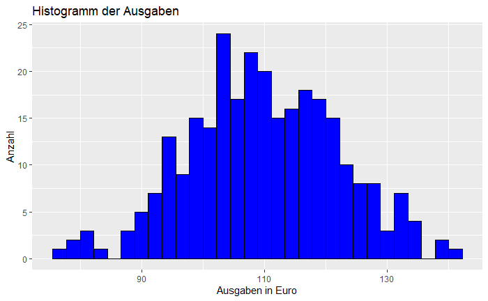

```r
# Erstellung eines ggplots. Hier wird ein Histogramm der Ausgaben erstellt, um die Verteilung der Ausgaben der Sommertouristen zu visualisieren. Die Balken des Histogramms werden blau gefärbt und mit schwarzen Konturen versehen. Das Histogramm erhält den Titel "Histogram der Ausgaben" und die Achsenbeschriftung wird dementsprechend angepasst.

ggplot(AS_2025, aes(x = Ausgaben)) +
  geom_histogram(fill = "blue", color = "black") +
  labs(title = "Histogramm der Ausgaben", x = "Ausgaben in Euro", y = "Anzahl")
```

## Aufgabe 3: Schätzen des Mittelwertes:

Der Mittelwert dieses Datensatzes liegt ungefähr bei 110 Euro.

## Aufgabe 4: Das 95% Konfidenzintervall mit dem Bootstrap berechnen:

```r
# Der Befehl set.seed(123) garantiert die Reproduzierbarkeit der Zufallsstichproben für das Bootstrapping-Verfahren. Mit specify() und generate() wurden aus den Originaldaten 1000 neue Stichproben durch Ziehen mit Zurücklegen erzeugt. Die Funktion calculate(stat = "mean") berechnet für jede dieser Simulationen den Mittelwert. Das Ergebnis in bootstrap_dist bildet die Grundlage für die Berechnung des 95 %-Konfidenzintervalls.

set.seed(123)

bootstrap_dist <- AS_2025 %>%
  specify(response = Ausgaben) %>%
  generate(reps = 1000, type = "bootstrap") %>%
  calculate(stat = "mean")

bootstrap_dist
```

```
Response: Ausgaben (numeric)
```

| replicate | stat |
| --- | --- |
| 1 | 110.4382 |
| 2 | 109.1825 |
| 3 | 110.8910 |
| 4 | 110.0916 |
| 5 | 109.3007 |
| 6 | 109.7078 |
| 7 | 110.2862 |
| 8 | 109.6462 |
| 9 | 109.9863 |
| 10 | 110.4377 |

[output cut: 990 more lines]

```r
# Die Funktion get_confidence_interval() extrahiert aus der Verteilung der Bootstrap-Mittelwerte das 95 %-Konfidenzintervall. Der Parameter level = 0.95 gibt das Konfidenzintervallniveau an, während type = percentile die Methode zur Berechnung des Intervalls festlegt. Das Ergebnis wird in der Variable percentile_ci gespeichert.

percentile_ci <- bootstrap_dist %>%
  get_confidence_interval(level = 0.95, type = "percentile")

percentile_ci
```

| lower_ci | upper_ci |
| --- | --- |
| 108.3821 | 111.2547 |

## Antwortsatz für die KölnTourismus GmbH:

Mit einer Wahrscheinlichkeit von 95 % liegt der tatsächliche Mittelwert aller Tagesausgaben der Sommertouristen in der Stadt Köln im Jahr 2025in einem Bereich zwischen 108,38 Euro und 111,25 Euro.

## Vorarbeit Forschungsfrage:

```r
# Die Funktion get_confidence_interval() extrahiert aus der Verteilung der Bootstrap-Mittelwerte das 95 %-Konfidenzintervall. Der Parameter level = 0.99 gibt das Konfidenzintervallniveau an, während type = percentile die Methode zur Berechnung des Intervalls festlegt. Das Ergebnis wird in der Variable percentile_ci gespeichert.

percentile_ci <- bootstrap_dist %>%
  get_confidence_interval(level = 0.99, type = "percentile")

percentile_ci
```

| lower_ci | upper_ci |
| --- | --- |
| 107.8942 | 111.6827 |

## Beantwortung der Forschungsfrage:

Wir können mit einer 99-prozentigen Sicherheit sagen, dass die tatsächlichen Durchschnittsausgaben der Sommertouristen im Jahr 2025 in Köln zwischen 107,89 Euro und 111,68 Euro.

# Lineare Regression mit einer erklärenden Variable

## Forschungsfrage: Besteht ein linearer Zusammenhang zwischen dem mittleren Preis eines Restaurants und der Bewertung des Essens?

Hypothese:Da wir untersuchen, ob ein linearer Zusammenhang zwischen dem Preis und der Bewertung des Essens besteht, formulieren wir folgende Hypothesen:

Nullhypothese H0: Es besteht kein linearer Zusammenhang zwischen dem Preis und der Bewertung des Essens (β₁ = 0).; Alternativhypothese H1:Es besteht ein linearer Zusammenhang zwischen dem Preis und der Bewertung des Essens (β₁ ≠ 0).

## 2: Untersuchen Sie zunächst, ob die Voraussetzungen für die Anpassung des linearen Modells erfüllt sind.

```r
#Mit head() betrachten wir die ersten Zeilen des Datensatzes, um die Struktur und die Variablen zu überprüfen.
head(B_2025)
```

[output not shown]

```r
#Mit str() kontrollieren wir, ob die Variablen die richtigen Datentypen haben und somit für die Regressionsanalyse geeignet sind.
str(B_2025)
```

[output not shown]

```r
#Zur explorativen Analyse erstellen wir ein Streudiagramm, um den Zusammenhang zwischen der Bewertung des Essens (x-Achse) und dem Preis (y-Achse) visuell zu untersuchen. Zusätzlich wird eine Regressionsgerade eingezeichnet, um einen möglichen linearen Trend sichtbar zu machen.
ggplot(data = B_2025, aes(x = Essen, y = Preis)) +
  geom_point() +
  geom_smooth(method = "lm", se = FALSE)
```

[output not shown]

Das Streudiagramm zeigt einen deutlich positiven Zusammenhang zwischen der Essensbewertung und dem Preis. Mit steigender Bewertung nimmt tendenziell auch der Preis zu. Der Zusammenhang wirkt annähernd linear, sodass die Annahme der Linearität erfüllt erscheint.

```r
#Zur Überprüfung der Modellannahmen stellen wir die Residuen gegen die angepassten Werte dar. So prüfen wir, ob ein systematisches Muster oder eine veränderte Streuung erkennbar ist.
mod <- lm(Preis ~ Essen, data = B_2025)

B_2025_res <- B_2025 %>%
  mutate(
    residuals = residuals(mod),
    fitted = fitted(mod)
  )

ggplot(B_2025_res, aes(x = fitted, y = residuals)) +
  geom_point() +
  geom_hline(yintercept = 0) +
  labs(x = "Angepasste Werte", y = "Residuen")
```

[output not shown]

Der Residualplot zeigt, dass die Residuen zufällig um die Nulllinie streuen. Es sind keine systematischen Muster oder Krümmungen erkennbar. Zudem wirkt die Streuung der Residuen über die angepassten Werte hinweg annähernd konstant. Die Annahmen der Linearität und einer gleichmäßigen Streuung der Residuen erscheinen somit erfüllt. Zunächst wurde die Struktur des Datensatzes mithilfe von head() und str() überprüft. Die relevanten Variablen liegen in geeigneter Form vor, sodass eine lineare Regression durchgeführt werden kann. Zur Überprüfung der Linearitätsannahme wurde ein Streudiagramm mit eingezeichneter Regressionsgerade erstellt. Es zeigt sich ein deutlich positiver und annähernd linearer Zusammenhang zwischen der Essensbewertung und dem Preis. Der Residualplot weist keine systematischen Muster oder erkennbare Trichterform auf. Die Residuen streuen zufällig um die Nulllinie und zeigen eine gleichmäßige Verteilung über die angepassten Werte hinweg. Insgesamt sind die Voraussetzungen für die Anpassung eines linearen Regressionsmodells erfüllt.

## 3: Untersuchen Sie, ob es einen linearen Zusammenhang zwischen dem Preis (abhängige Variable) und der Bewertung des Essens (unabhängige Variable) gibt.

### 3a: Untersuchen Sie, ob die Modellannahmen erfüllt sind.

Wie in Aufgabe 2 gezeigt wurde, sind die Annahmen der Linearität und Homoskedastizität erfüllt. Der Residualplot zeigt keine systematischen Muster, sodass das lineare Regressionsmodell angewendet werden kann.

### 3b: Interpretieren Sie die Modellparameter.

```r
#Mit lm() schätzen wir ein lineares Regressionsmodell, in dem der Preis durch die Essensbewertung erklärt wird.
mod <- lm(Preis ~ Essen, data = B_2025)
```

```r
#Mit der Funktion tidy() lassen wir uns die geschätzten Modellparameter, deren Standardfehler sowie die zugehörigen p-Werte anzeigen, um die Bedeutung der Steigung statistisch zu beurteilen.
mod %>% tidy()
```

[output not shown]

```r
#Mit glance() betrachten wir Kennzahlen zur Modellgüte, insbesondere das Bestimmtheitsmaß R^2, das angibt, welcher Anteil der Varianz des Preises durch die Essensbewertung erklärt wird.
mod %>% glance()
```

[output not shown]

Das geschätzte Regressionsmodell lautet: Preis = 21.71 + 1.18 · Essen Der Achsenabschnitt (Intercept) beträgt 21.71. Dieser Wert gibt den geschätzten Preis an, wenn die Essensbewertung den Wert 0 annimmt. Da eine Bewertung von 0 in der Praxis kaum vorkommt, besitzt dieser Wert vor allem eine rechnerische Bedeutung. Der Koeffizient der Variable Essen beträgt 1.18. Dies bedeutet, dass sich der Preis eines Restaurants im Durchschnitt um etwa 1.18 Geldeinheiten erhöht, wenn die Essensbewertung um einen Punkt steigt. Der zugehörige p-Wert ist kleiner als 0.001, sodass der Zusammenhang statistisch hoch signifikant ist. Die Nullhypothese eines fehlenden linearen Zusammenhangs kann somit verworfen werden.

### 3c: Wie viel Prozent der Varianz erklärt das Modell? Ist es ein gutes Modell?

Aus der Tabelle glance() aus Aufgabe 3b geht hervor, dass das Bestimmtheitsmaß R^2 einen Wert von 0.54 annimmt. Dies bedeutet, dass etwa 54 % der Varianz des Preises durch die Essensbewertung erklärt werden. Das Modell weist somit eine mittlere bis gute Erklärungskraft auf. Ein Teil der Preisvariation wird durch die Essensbewertung beschrieben, jedoch spielen vermutlich auch weitere Einflussfaktoren eine Rolle.

## Abschliesend zur Forschungsfrage:

Wir wollten untersuchen, ob ein linearer Zusammenhang zwischen der Essensbewertung und dem Preis eines Restaurants besteht. Die lineare Regression zeigt einen statistisch signifikanten positiven Zusammenhang. Der geschätzte Steigungskoeffizient ist positiv und hoch signifikant (p < 0.001). Da der p-Wert deutlich kleiner als 0.05 ist, wird die Nullhypothese H0 verworfen. Zudem erklärt das Modell mit einem R^2 von 0.54 etwa 54 % der Preisvarianz. Die Forschungsfrage kann somit dahingehend beantwortet werden, dass ein signifikanter positiver linearer Zusammenhang zwischen der Bewertung des Essens und dem Preis besteht: Mit steigender Essensbewertung steigt im Durchschnitt auch der Preis.

# Lineare Regression mit mehreren erklärenden Variablen

## Aufgabenstellung:

Möglicherweise besteht zwischen dem Preis und den Variablen Altstadt und Service ebenfalls ein Zusammenhang. Formulieren Sie eine Forschungsfrage für diese Aufgabe.

A: Passen Sie ein multivariates Modell mit allen drei erklärenden Variablen an, nämlich Essen, Service und Altstadt.

B: Ist dieses Modell besser als das Modell mit nur einer erklärenden Variable?

C: Sind alle Modellparameter signifikant? Welcher Test (Nullhypothese, Alternativhypothese) liegt dieser Entscheidung zugrunde? Sie dürfen davon ausgehen, dass alle Voraussetzungen für den Test erfüllt sind.

D: Interpretieren Sie die Modellparameter.

## Forschungsfrage:

Gibt es einen linearen Zusammenhang zwischen dem mittleren Preis und der Bewertung des Service unter Berücksichtigung des Standortes?

## Aufgaben:

### A:

Anpassung eines multivariaten linearen Regressionsmodells, in dem der Preis durch die Variablen Essen, Service und Altstadt erklärt wird. Das Modell wird mit der Funktion lm() geschätzt, wobei die abhängige Variable Preis ist und die unabhängigen Variablen Essen, Service und Altstadt sind.

```r
#Anpassung eines multivariaten linearen Regressionsmodells mit den erklärenden Variablen Essen, Service und Altstadt. Das Modell wird mit lm() geschätzt, wobei Preis die abhängige Variable ist. Die Daten stammen aus dem Datensatz B_2025. Die Funktion tidy() wird verwendet, um die geschätzten Modellparameter, deren Standardfehler und die zugehörigen p-Werte anzuzeigen.

mod_multivariat <- lm(Preis ~ Essen + Service + Altstadt, data = B_2025)
mod_multivariat %>% tidy()
```

[output not shown]

### B:

Vergleich des multivariaten linearen Regressionsmodells mit dem vorherigen Modell, einem linearen Regressionsmodell mit nur einer erklärenden Variable.

Zunächst betrachtet man den p.value der beiden Modelle als auch den Wert der adjusted R², da uns diese aufschluss über die Qualität der beiden Modelle liefern. Zusätzlich dazu wird ein ANOVA vergleich durchgeführt um 100% sicherheit zu gewährleisten.

```r
#Vergleich des multivariaten Modells mit dem vorherigen Modell, das nur die Essensbewertung als erklärende Variable enthält. Hierfür werden die Funktionen glance() verwendet, um die Modellgüte-Kennzahlen wie das Bestimmtheitsmaß R^2 und den p-Wert für beide Modelle zu extrahieren. Anschließend werden die relevanten Kennzahlen in einem neuen Dataframe vergleich zusammengeführt, um die Modelle hinsichtlich ihrer Erklärungskraft und Signifikanz zu vergleichen.

mult <- glance(mod_multivariat)
eins <- glance(mod)

vergleich <- bind_rows(
  mult %>% select(adj.r.squared, p.value) %>% mutate(modell = "mult"),
  eins %>% select(adj.r.squared, p.value) %>% mutate(modell = "eins")
)

vergleich
```

[output not shown]

Der adjusted R² Wert des multivariaten Modells ist mit 0,968 deutlich höher als der des Modells mit nur einer erklärenden Variable, dieser liget bei 0,537, was darauf hindeutet, dass das multivariate Modell eine bessere Anpassung an die Daten bietet. Zusätzlich gibt der p.value des multivariaten Modells aufschluss darüber das diese Modell besser ist, denn das Multivariate Modell ist um 69 Nachkommastellen kleiner als das Modell mit einer erklärenden Variable.

```r
#Alternativ kann auch ein ANOVA-Test durchgeführt werden, um die Modelle direkt zu vergleichen. Hierfür wird die Funktion anova() verwendet, um die beiden Modelle zu vergleichen und den p-Wert für den Vergleich zu erhalten. Ein signifikanter p-Wert würde darauf hinweisen, dass das multivariate Modell eine signifikant bessere Anpassung an die Daten bietet als das Modell mit nur einer erklärenden Variable.

anova(mod, mod_multivariat)
```

[output not shown]

Der ANOVA-Modellvergleich zeigt, dass das multiple Regressionsmodell den Preis signifikant besser erklärt als das einfache Modell, erkennbar an einem F-Score von F = 838.42 und einem p-Wert von p< 0.001. Die zusätzlichen Variablen Service und Altstadt tragen somit signifikant zur Erklärung der Preisvariation bei.

Alles in allem lässt sich anhand der zwei Kennzahlen adjusted R², p-Wert und dem ANOVA-Test schlussfolgern, dass das multivariate Modell mit den Variablen Essen, Service und Altstadt eine deutlich bessere Erklärungskraft für die Preisvariation bietet als das Modell mit nur der Essensbewertung. Die zusätzlichen Variablen tragen signifikant zur Erklärung des Preises bei, was durch die signifikanten p-Werte und den höheren adjusted R² Wert, als auch den ANOVA Test bestätigt wird.

### C:

Signifikanz der Modellparameter anhand der p-Werte beurteilen.

Nullhypothese H0: Der jeweilige Koeffizient ist gleich 0 es gibt keinen Beeinflussung.

Alternativhypothese H1: Der jeweilige Koeffizient ist ungleich 0 es gibt eine Beeinflussung.

Ein Parameter wird als signifikant betrachtet, wenn der zugehörige p-Wert kleiner als 0.05 ist, was zur Ablehnung der Nullhypothese führt.

```r
#Beurteilung der Signifikanz der Modellparameter anhand der p-Werte. Hierfür wird die Funktion tidy() verwendet, um die geschätzten Modellparameter, deren Standardfehler und die zugehörigen p-Werte anzuzeigen. Anschließend werden die relevanten Informationen in einem neuen Dataframe sig zusammengeführt, um die Signifikanz der einzelnen Parameter zu beurteilen. Es wird eine neue Spalte signifikant erstellt, die angibt, ob der jeweilige Parameter signifikant ist (Ja) oder nicht (Nein), basierend auf einem Signifikanzniveau von 0.05.
sig <- tidy(mod_multivariat)

sig %>%
  select(term, p.value) %>%
  mutate(signifikant = ifelse(p.value < 0.05, "Ja", "Nein"))
```

[output not shown]

Alle drei Modellparameter Essen, Service und Altstadt sind signifikant, da ihre p-Werte alle kleiner als 0.05 sind. Die Nullhypothese, dass der jeweilige Koeffizient gleich 0 ist, also keine Beeinflussung vorliegt, wird für alle drei Variablen abgelehnt.

Dies bedeutet, dass sowohl die Bewertung des Essens, die Bewertung des Service als auch die Lage in der Altstadt einen signifikanten Einfluss auf den Preis haben. Zusätzlich ist aufzuführen, dass der p.value < 0.001 ist daraus lässt sich ableiten, dass die Modellparameter hochgradig signifikant sind.

### D:

Interpretation der Modellparameter:

```r
#
mod_multivariat %>% tidy()
```

[output not shown]

Regressionsgleichung:

Preis = 5.54 + 1.13 * Essen + 1.13 * Service + 1.78 * Altstadt

Intercept: Wert: 5.54 Der Achsenabschnitt gibt den geschätzten Preis an, wenn alle erklärenden Variablen (Essen, Service und Altstadt) den Wert 0 annehmen.

Essen: Wert: 1.13 Wenn die Bewertung des Essens um eine Einheit steigt, erhöht sich der erwartete Preis im Durchschnitt um etwa 1.13 Einheiten, bei konstantem Service und gleicher Lage.

Service: Wert: 1.13 Wenn die Servicebewertung um eine Einheit steigt, erhöht sich der erwartete Preis im Durchschnitt ebenfalls um etwa 1.13 Einheiten, bei konstantem Essen und gleicher Lage.

Altstadt: Wert: 1.78 Restaurants in der Altstadt sind im Durchschnitt etwa 1.78 Preiseinheiten teurer als vergleichbare Restaurants außerhalb der Altstadt, bei gleichen Bewertungen für Essen und Service.

Alle Variablen haben sehr kleine p-Werte, p < 0.001. Damit sind alle Effekte statistisch hochsignifikant, was darauf hinweist, dass Essen, Service und die Lage in der Altstadt einen signifikanten Einfluss auf den Preis haben.

## Abschließend zur Forschungsfrage:

Es wurde untersucht, ob es einen linearen Zusammenhang zwischen dem Preis eines Restaurants und der Bewertung des Service unter Berücksichtigung des Standortes gibt. Das multivariate Regressionsmodell zeigt, dass sowohl die Bewertung des Essens, die Bewertung des Service als auch die Lage in der Altstadt hochgradig signifikante Einflussfaktoren für den Preis sind, erkennbar dara, dass die jeweiligen p.values < als 0.001 sind. Zudem wird die in Aufgabe C formulierte Nullhypotese abgelehnt, da wir p.values < als 0.05 haben, und somit die Alternativhypothese H1 angenommen. H1: Der jeweilige Koeffizient ist ungleich 0 es gibt eine Beeinflussung

Das Modell erklärt mit einem adjusted R² von 0.9680971, einen deutlich höheren Anteil der Preisvarianz, um genau zu sein 97%, als das einfache Modell mit nur einer erklärenden Variable, welches mit einem adjusted R² von 0.5371918 nur etwa 54% der Preisvarianz erklärt. Bei einem so ausgefallen gutem adjusted R² ist allerdings forsicht geboten, dieses ergebnis ist fast zu gut um wahr zu sein und deshalb solte unbedingt auf etwaige fehler, bzw. Ungereimtheiten geschaut werden. Und die datenlage nochmals überprüft werden. Dies würde allerdings den Rahmen dieser Arbeit sprengen, weswegen sich dagegen entschieden wurde.

Insgesamt lässt sich somit festhalten, dass es einen signifikanten linearen Zusammenhang zwischen dem Preis und den Variablen Essen, Service und Altstadt gibt.

# Reflektionsaufgaben:

Reflexion (Individualaufgabe, Joram): Am Anfang des Semesters hatte ich ehrlich gesagt nicht wirklich eine Vorstellung davon, was Statistik eigentlich bedeutet. Ich dachte, es geht vor allem um Formeln und Rechnen. Im Laufe der Vorlesungen habe ich aber gemerkt, dass es viel mehr um das Arbeiten mit Daten geht und darum, wie man zu begründeten Aussagen kommt. Besonders hängen geblieben ist bei mir das Thema Datenerhebung. Mir war vorher nicht klar, wie wichtig es ist, woher die Daten kommen. Der Unterschied zwischen Beobachtungsstudie und Experiment hat mir gezeigt, dass man nicht einfach aus jedem Zusammenhang auf eine Ursache schließen kann. Auch das Thema Stichprobe und Grundgesamtheit fand ich wichtig, weil man meistens ja nicht alle untersuchen kann, sondern nur einen Teil und trotzdem Aussagen über alle machen will. In der Geographie spielen empirische Daten eine große Rolle, weil viele Fragen nur mit echten Daten beantwortet werden können. Zum Beispiel der Zusammenhang zwischen Bruttoinlandsprodukt und Lebenserwartung. Durch Streudiagramme konnte man sehen, dass es einen positiven Zusammenhang gibt. Gleichzeitig wurde aber auch klar, dass ein Zusammenhang nicht automatisch kausal ist. Mit Histogrammen, Boxplots und später der linearen Regression habe ich gelernt, Daten systematisch auszuwerten. Am Anfang war mir zum Beispiel nicht klar, was die Steigung oder das Bestimmtheitsmaß wirklich aussagen. Jetzt verstehe ich besser, wie man so ein Modell interpretiert und was es bedeutet, wenn ein Modell nur einen Teil der Variabilität erklärt. Insgesamt hat sich mein Verständnis von Statistik verändert. Ich sehe es nicht mehr nur als Rechnen, sondern als Werkzeug, um Daten kritisch zu betrachten und wissenschaftliche Fragen nachvollziehbar zu beantworten.

Reflexion (Individualaufgabe, Jago): Am Anfang des Semesters hatte ich bereits grundlegende Kenntnisse in der Datenverarbeitung, zum Beispiel im Umgang mit Tabellen, Datensätzen und einfachen Auswertungen. Statistik habe ich jedoch eher als ein theoretisches Fach wahrgenommen, das hauptsächlich aus Formeln und mathematischen Berechnungen besteht. Im Laufe der Veranstaltung hat sich mein Verständnis deutlich erweitert. Mir wurde klar, dass Statistik vor allem ein Werkzeug ist, um Daten systematisch zu analysieren und daraus nachvollziehbare Aussagen über reale Fragestellungen abzuleiten. Ein wichtiger Bestandteil der Statistik ist die Datenerhebung. Dabei habe ich gelernt, dass die Qualität der späteren Analyse stark davon abhängt, wie die Daten erhoben wurden. Aus der Datenverarbeitung kannte ich da schon das ein oder andere Schreckgespenst, im Kurs habe ich dan allerdings Mittel und Wege kennen gelernt an vernünftige Datensätze zu kommen, wie z.B. die von Eurostat bereitgestellten Daten. Hier besonders interessant fand ich die Empirische Daten, welche man auf Eurostat herunterladen kann. Sie spielen in der Geographie eine zentrale Rolle, da viele geographische Fragestellungen nur mithilfe realer Messungen oder Beobachtungen beantwortet werden können. Ein Beispiel aus der Übung ist die Analyse von Zusammenhängen zwischen verschiedenen Variablen in Datensätzen. Durch grafische Darstellungen wie Streudiagramme können mögliche Beziehungen sichtbar gemacht werden, etwa zwischen zwei kontinuierlichen Variablen. Dabei wurde auch deutlich, dass ein statistischer Zusammenhang nicht automatisch eine kausale Beziehung bedeutet. Für die Auswertung der Daten haben wir verschiedene Methoden der explorativen Datenanalyse kennengelernt. Dazu gehören zum Beispiel Histogramme, Boxplots oder Häufigkeitstabellen, mit denen man sich zunächst einen Überblick über die Verteilung der Daten verschaffen kann. Anschließend können auch statistische Modelle wie die lineare Regression eingesetzt werden, um Zusammenhänge zwischen Variablen genauer zu untersuchen. Dabei habe ich gelernt, wie man die Steigung eines Modells interpretiert und welche Bedeutung das Bestimmtheitsmaß für die Erklärung der Variabilität der Daten hat. Insgesamt hat sich mein Blick auf Statistik im Laufe des Semesters positiv verändert. Ich sehe Statistik heute weniger als reine, lästige Mathematik, sondern als wichtiges methodisches Werkzeug der wissenschaftlichen Arbeit. Durch statistische Methoden lassen sich Daten strukturiert analysieren und geographische Fragestellungen fundiert untersuchen.

Reflexion (Individualaufgabe, Alicia): Zu Semesterbeginn hatte ich kaum statistische Vorkenntnisse und konnte mir nicht wirklich vorstellen, was mich in der Veranstaltung Statistik und Datenanalyse erwartet. Statistik erschien mir zunächst sehr theoretisch und abstrakt. Im Laufe des Semesters hat sich mein Verständnis jedoch deutlich verändert. Ich habe gelernt, dass Statistik ein wichtiges Werkzeug ist, um Daten systematisch zu erfassen, auszuwerten und daraus Aussagen über geographische Fragestellungen abzuleiten. Ein zentraler Bestandteil der Statistik ist die Datenerhebung. Dabei wird zwischen Beobachtungsstudien und Experimenten unterschieden. In Beobachtungsstudien werden Daten gesammelt, ohne den Prozess selbst zu beeinflussen, zum Beispiel durch Befragungen oder durch die Beobachtung von Umweltprozessen über einen längeren Zeitraum. Experimente finden dagegen unter kontrollierten Bedingungen statt, bei denen bestimmte Variablen gezielt verändert werden, um ihren Einfluss zu untersuchen. In der Geographie spielen Beobachtungsstudien häufig eine große Rolle, da viele Prozesse, wie zum Beispiel Klimaveränderungen, nicht einfach experimentell untersucht werden können. Empirische Daten sind in der Geographie besonders wichtig, weil sie helfen, räumliche Muster und Zusammenhänge sichtbar zu machen. Ein Beispiel aus der Übung ist der Datensatz zu Palmer-Pinguinen, bei dem verschiedene Merkmale wie Schnabellänge, Flossenlänge und Körpergewicht gemessen wurden. Mithilfe der Daten kann untersucht werden, ob ein Zusammenhang zwischen der Flossenlänge und dem Körpergewicht besteht. Solche Analysen helfen dabei, ökologische Zusammenhänge besser zu verstehen. Für die Auswertung der Daten wird häufig zunächst eine explorative Datenanalyse durchgeführt. Dabei verschafft man sich einen ersten Überblick über die Daten und sucht nach möglichen Mustern oder Auffälligkeiten. Dazu können zum Beispiel Häufigkeitstabellen oder grafische Darstellungen wie Balken- oder Mosaikdiagramme genutzt werden. Diese helfen dabei, die Struktur der Daten zu erkennen und erste Zusammenhänge zwischen Variablen sichtbar zu machen. Im Laufe des Semesters habe ich verstanden, dass Statistik ein wichtiges Werkzeug für die geographische Forschung ist. Durch Datenerhebung und die anschließende Analyse lassen sich Zusammenhänge erkennen und wissenschaftlich begründete Aussagen über Umwelt und Gesellschaft treffen.